# Lecture #17: Snippets, Structured Programming II

Nicholas J. Gotelli

19 March 2020

### Creating code snippets

```
snippet msec
    # ${1:section label} --------------------------------------

snippet mbar
    ########################################

snippet mhead
    # --------------------------------------
    # ${1:script description}
    # 02 Apr 2020
    # NJG
    # --------------------------------------
    #

snippet mfun
    # --------------------------------------
    # FUNCTION ${1:function_name}
    # description: ${2:description}
    # inputs: ${3:input_description}
    # outputs: ${4:output_description}
    ########################################
    ${1:function_name} <- function(x=5) {

    # function body

    return("Checking...${1:function_name}")

    } # end of ${1:function_name}
    # --------------------------------------
```

### Building a Function Template

Save the following as `FunctionTemplate.txt`

```
##################################################
# FUNCTION: FunctionName
# one line description
# input: x
# output: x
#-------------------------------------------------
FunctionName <- function() {


 return("testing..............FunctionName")
}
```

### Pseudocode

*pseudocode* is a simple list of instructions that gives the overall flow of the program without (yet) specifying the exact language and functions. At the most basic, it is just a list of what a program will do. Here, for example is generic pseudocode that describes about 95% of the programming chores we face:

```
Get data
Calculate stuff
Summarize output
Graph results
```

### Structured Programming With PseudoCode And Functions

Let’s use the pseudocode to build a program.

```
GetData()
CalculateStuff()
SummarizeOutput()
GraphResults()
```

Now we use our template to build 4 functions and then run them

```r
# Sample program to illustrate structured programming with functions
# 9 March 2017
# NJG

# All functions must be declared at the top before they are used
##################################################
# FUNCTION: GetData
# one line description
# input: x
# output: x
#-------------------------------------------------
GetData <- function() {


 return("testing..............GetData")
}
##################################################
# FUNCTION: CalculateStuff
# one line description
# input: x
# output: x
#-------------------------------------------------
CalculateStuff <- function() {


 return("testing..............CalculateStuff")
}
##################################################
# FUNCTION: SummarizeOutput
# one line description
# input: x
# output: x
#-------------------------------------------------
SummarizeOutput <- function() {


 return("testing..............SummarizeOutput")
}
##################################################
# FUNCTION: GraphResults
# one line description
# input: x
# output: x
#-------------------------------------------------
GraphResults <- function() {


 return("testing..............GraphResults")
}
##################################################
library(ggplot2)
GetData()
CalculateStuff()
SummarizeOutput()
GraphResults()
```

### Sourcing Functions In A Separate Script File

1. Cut and copy all functions to new Rscript `MyFunctions.R`
2. Create new file called `MyShortProgram.R`
3. Add following code to the new program:

```
source("MyFunctions.R")
GetData()
CalculateStuff()
SummarizeOutput()
GraphResults()
```

the `source` function runs a specified R script file automatically. It is equivalent to running `<Control><Shift><Enter>` from within a script file.

#### Advantages of Sourcing

1. Let’s you build a library of reusable functions
2. Corrections can be made once and then applied to all programs that use them

#### Disadvantages of Sourcing

1. Breaks code into two separate files, both of which must be present.
2. Discourages minor tweaks to functions because they will affect other programs.

#### Compromise solution

1. Maintain a single R script that contains the functions you have built.
2. Cut and paste functions that you want from your function file to your script file.
3. When you create new functions that are useful, append a copy to your function file.

#### Building the `CalculateStuff()` Function

```r
##################################################
# FUNCTION: FitRegressionModel
# Fits an ordinary least squares regression model
# input: x and y vectors of numeric. Must be same length
# output: entire model summary from lm
#-------------------------------------------------
FitRegressionModel <- function(xVar=runif(10),yVar=runif(10)) {
dataFrame <- data.frame(xVar,yVar)
regModel <- lm(yVar~xVar,data=dataFrame)
return(summary(regModel))
}
FitRegressionModel()
```

```
##
## Call:
## lm(formula = yVar ~ xVar, data = dataFrame)
##
## Residuals:
##      Min       1Q   Median       3Q      Max
## -0.55849 -0.18741  0.00518  0.27915  0.36165
##
## Coefficients:
##              Estimate Std. Error t value Pr(>|t|)
## (Intercept)  0.586399   0.158043   3.710  0.00595 **
## xVar        -0.001826   0.322885  -0.006  0.99563
## ---
## Signif. codes:  0 '***' 0.001 '**' 0.01 '*' 0.05 '.' 0.1 ' ' 1
##
## Residual standard error: 0.3238 on 8 degrees of freedom
## Multiple R-squared:  4e-06,  Adjusted R-squared:  -0.125
## F-statistic: 3.2e-05 on 1 and 8 DF,  p-value: 0.9956
```

#### Building the `SummarizeOutput()` Function

```r
##################################################
# FUNCTION: SummarizeOutput
# pull elements from model summary list
# input: list from summary call of lm
# output: vector of regression residuals
#-------------------------------------------------
SummarizeOutput <- function(z=NULL) {
if(is.null(z)) {
  z <- summary(lm(runif(10)~runif(10)))
}
  return(z$residuals)
}
SummarizeOutput()
```

```
##           1           2           3           4           5           6
##  0.32861405  0.40070335  0.06352599 -0.49400602 -0.56110855  0.24508395
##           7           8           9          10
## -0.31417346  0.40730268 -0.13249694  0.05655495
```

#### Building the `GraphResults()` Function

```
## Message: Regression graph created
```

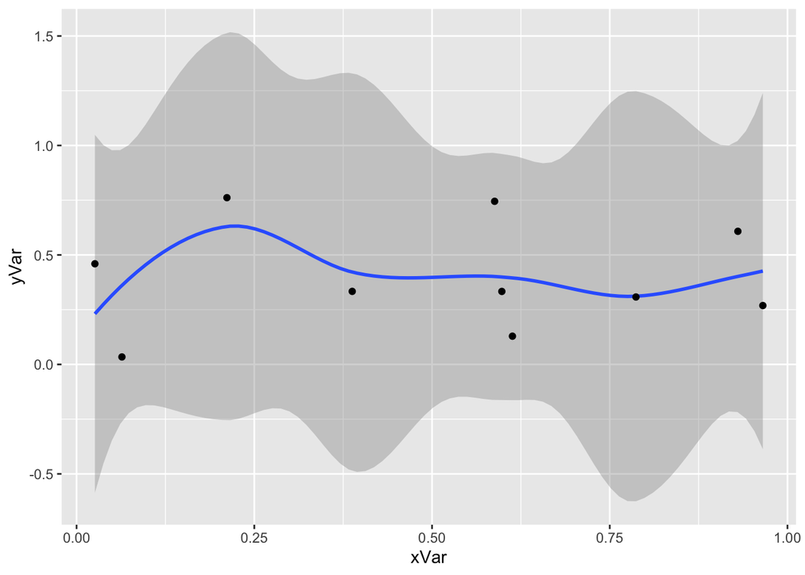

```r
library(ggplot2)

##################################################
# FUNCTION: GraphResults
# graph data and fitted OLS line
# input: x and y vectors of numeric. Must be same length
# output: creates graph
#-------------------------------------------------
GraphResults <- function(xVar=runif(10), yVar=runif(10)) {
dataFrame <- data.frame(xVar,yVar)
# #plot(y=dataFrame$yVar,
#      x=dataFrame$xVar,
#      pch=21,
#      bg="lightblue",
#      cex=2)
p1 <- qplot(data=dataFrame,x=xVar,y=yVar,geom=c("smooth","point"))
print(p1)
regModel <- lm(yVar~xVar,data=dataFrame)
# abline(regModel)
message("Message: Regression graph created")
}
GraphResults()
```

```
## Message: Regression graph created
```

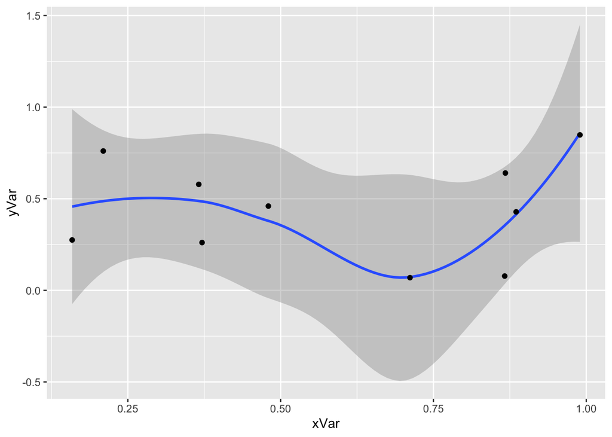

```r
str(GraphResults())
```

#### Building the `GetData()` Function

```r
##################################################
# FUNCTION: GetData
# read in a .csv file
# input: .csv file
# output: data frame
#-------------------------------------------------
GetData <- function(fileName=NULL) {
if(is.null(fileName)) {
  dataFrame <- data.frame(ID=101:110,
                          varA=runif(10),
                          varB=runif(10))
}  else {
  dataFrame <- read.table(file=fileName,
                          header=TRUE,
                          sep=",",
                          stringsAsFactors=FALSE)
  }
  return(dataFrame)
}


GetData()
```

```
##     ID       varA       varB
## 1  101 0.60530974 0.15295086
## 2  102 0.84002628 0.89750180
## 3  103 0.25350860 0.59276532
## 4  104 0.89864456 0.42631633
## 5  105 0.43393886 0.11329924
## 6  106 0.32377042 0.09264996
## 7  107 0.94074319 0.65803383
## 8  108 0.48914596 0.36012751
## 9  109 0.08735431 0.82278118
## 10 110 0.64233941 0.16758207
```

#### Linking each of the functions

Now each function works, but they are all using their defaults and are not “talking” to each other. To link them, we first must create a very small number of **global variables** which can be passed down to some of our functions as parameters. In this case, we need 3 of them:

1. The name of the inputdata file
2. The column of data in the data frame that contains the x variable
3. The column of data in the data frame that contains the y variable

```
## Message: Regression graph created
```

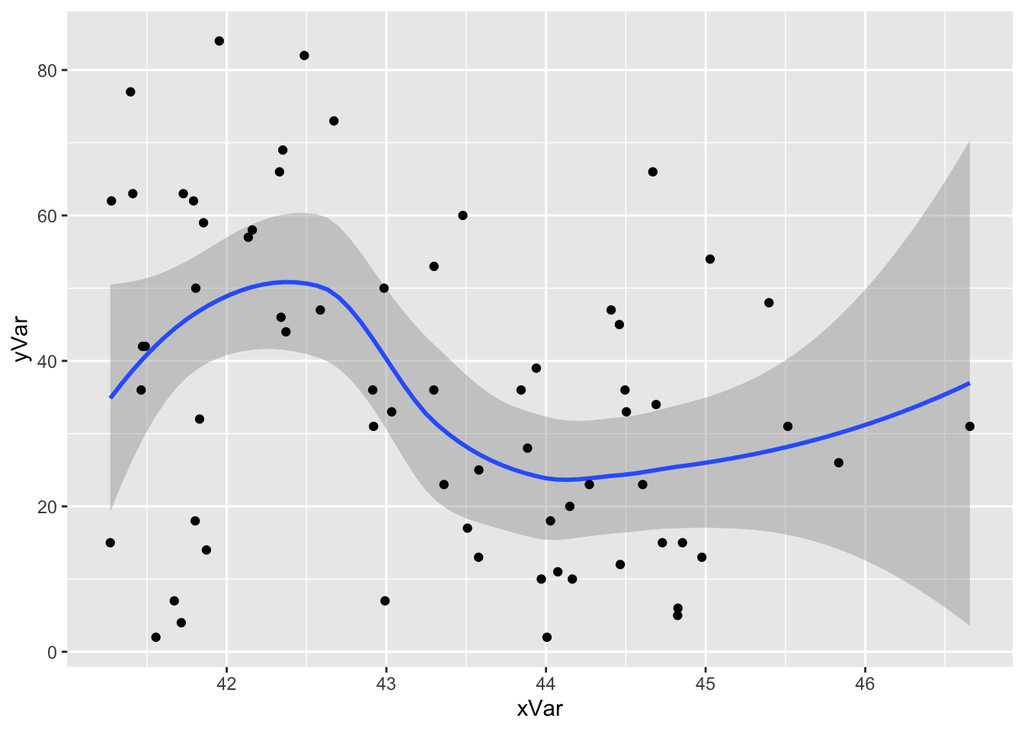

```r
# Global variables
#----------------------------------------------
antFile <- "antcountydata.csv" # New England ant county data
xCol <- 7 # column 7, latitude center of each county
yCol <- 5 # column 5, number of ant species
#----------------------------------------------

# Program body
temp1 <- GetData(fileName=antFile) # construct the data frame

x <- temp1[,xCol] # extract the predictor variable
y <- temp1[,yCol] # extract the response variable

temp2 <- FitRegressionModel(xVar=x,yVar=y) # fit the model
temp3 <- SummarizeOutput(temp2) # extract the residuals

GraphResults(xVar=x, yVar=y) # create graph
```

```r
print(temp3) # show the residuals
```

```
##           1           2           3           4           5           6
## -31.5179761   6.3693797  18.2940950  -9.4758482  17.2418354  -3.3377840
##           7           8           9          10          11          12
##  15.6301192 -11.5030669 -20.9155154  13.5082804   3.3544234 -13.5407808
##          13          14          15          16          17          18
##  37.8025885  17.3945424 -11.0008744 -20.4060278   6.8632030  23.7246607
##          19          20          21          22          23          24
##   4.0813849 -21.9626993   7.3611177   3.9092082  27.7361831  25.3867951
##          25          26          27          28          29          30
##  18.9470317   3.4144254 -25.6505262  31.1661410  34.0339177   7.5745984
##          31          32          33          34          35          36
##  15.1429775   5.2471194  42.0340705  15.5211944  16.2771230  41.1628367
##          37          38          39          40          41          42
##  25.1963600  28.3076081 -17.4566146  -4.4290959  -6.6275642   5.9125214
##          43          44          45          46          47          48
##   6.8672727  -1.6550865   0.4062771  12.7272502  17.4131927 -12.2505136
##          49          50          51          52          53          54
## -40.1206313 -37.3573953 -42.9777087 -29.2709870  -3.4287865 -13.6531355
##          55          56          57          58          59          60
##  -4.0147971 -17.2972683  15.6723473 -12.8757467 -12.1965886 -22.3598143
##          61          62          63          64          65          66
##  -5.5402651 -29.7718759 -21.3500257 -21.0817810  -7.3419565 -30.2400476
##          67
##  -9.0732969
```

```r
print(temp2) # show the model summary
```

```
##
## Call:
## lm(formula = yVar ~ xVar, data = dataFrame)
##
## Residuals:
##     Min      1Q  Median      3Q     Max
## -42.978 -13.597   0.406  15.651  42.034
##
## Coefficients:
##             Estimate Std. Error t value Pr(>|t|)
## (Intercept)  268.973     82.154   3.274  0.00170 **
## xVar          -5.390      1.898  -2.840  0.00601 **
## ---
## Signif. codes:  0 '***' 0.001 '**' 0.01 '*' 0.05 '.' 0.1 ' ' 1
##
## Residual standard error: 20.72 on 65 degrees of freedom
## Multiple R-squared:  0.1104, Adjusted R-squared:  0.09672
## F-statistic: 8.067 on 1 and 65 DF,  p-value: 0.006012
```